# Regresión Logística y Validación Cruzada

### José Ricardo Jáuregui Guevara - 608995

```python
import pandas as pd
import numpy as np
import matplotlib.pyplot as plt
import seaborn as sns
from sklearn.linear_model import LogisticRegression
from sklearn.model_selection import train_test_split, StratifiedKFold, cross_validate
from sklearn.metrics import (confusion_matrix, roc_auc_score, roc_curve, accuracy_score, precision_score, recall_score, f1_score, ConfusionMatrixDisplay)
from sklearn.preprocessing import StandardScaler
```

## 1. Definición del Problema de Clasificación

Los datos utilizados provienen de la Encuesta Nacional de Ingresos y Gastos de los Hogares (ENIGH) 2014, la cual recopila información socioeconómica de 58,125 hogares en México. Inicialmente, en el proyecto se abordó el ingreso corriente (ing_cor) como una variable numérica continua, empleando técnicas de regresión para su análisis. Sin embargo, en esta fase se reformula el enfoque para convertirlo en un problema de clasificación binaria.

Con el fin de crear la variable categórica llamada alto_ingreso, se empleó la mediana del ingreso corriente anual como punto de corte para diferenciar los hogares. La regla de clasificación es la siguiente:

- Se asigna el valor 1 (alto ingreso) si el ingreso del hogar supera la mediana.
- Se asigna el valor 0 (bajo ingreso) en caso contrario.

La elección de la mediana como umbral, en lugar de la media aritmética, responde a dos razones fundamentales. Primero, la mediana es una medida estadística resistente a valores atípicos o extremos, lo cual es crucial dado que la distribución del ingreso suele presentar una marcada asimetría hacia la derecha (es decir, existen pocos hogares con ingresos muy elevados que distorsionan el promedio). Segundo, al utilizar la mediana se garantiza, por definición, que los grupos resultantes tengan un tamaño similar (clases balanceadas), lo cual facilita significativamente el proceso de entrenamiento de los modelos de clasificación.

Esta nueva variable tiene una aplicación práctica importante para el diseño de políticas públicas, ya que permite analizar y determinar qué características del hogar son predictores clave de que una familia se sitúe por arriba o por abajo de la mediana nacional de ingresos.

```python
df = pd.read_csv('mcs_concentrado_2014_concil_2010.csv')
print(df.shape)
df.head()
```

```
(58125, 59)
```

|  | proyecto | folioviv | foliohog | ubica_geo | ageb | tam_loc | est_socio | est_dis | upm | factor_hog | ... | jubilacion | becas | donativos | remesas | bene_gob | transf_hog | trans_inst | estim_alqu | otros_ing | smg |
| --- | --- | --- | --- | --- | --- | --- | --- | --- | --- | --- | --- | --- | --- | --- | --- | --- | --- | --- | --- | --- | --- |
| 0 | 1 | 100014201 | 1 | 10010000 | 000-0 | 1 | 3 | 7 | 2620 | 168 | ... | 0.00 | 2347.82 | 2788.04 | 0.0 | 0.0 | 0.00 | 0.0 | 11612.90 | 0.0 | 5739.3 |
| 1 | 1 | 100014202 | 1 | 10010000 | 000-0 | 1 | 3 | 7 | 2620 | 168 | ... | 26413.04 | 11739.13 | 0.00 | 0.0 | 0.0 | 0.00 | 0.0 | 8709.67 | 0.0 | 5739.3 |
| 2 | 1 | 100014203 | 1 | 10010000 | 000-0 | 1 | 3 | 7 | 2620 | 168 | ... | 0.00 | 0.00 | 0.00 | 0.0 | 0.0 | 10065.88 | 0.0 | 0.00 | 0.0 | 5739.3 |
| 3 | 1 | 100014204 | 1 | 10010000 | 000-0 | 1 | 3 | 7 | 2620 | 168 | ... | 0.00 | 0.00 | 0.00 | 0.0 | 0.0 | 0.00 | 0.0 | 10161.29 | 0.0 | 5739.3 |
| 4 | 1 | 100014205 | 1 | 10010000 | 000-0 | 1 | 3 | 7 | 2620 | 168 | ... | 0.00 | 880.43 | 0.00 | 0.0 | 0.0 | 0.00 | 0.0 | 11612.90 | 0.0 | 5739.3 |

5 rows × 59 columns

Se procede a cargar el archivo de datos correspondiente a la Encuesta Nacional de Ingresos y Gastos de los Hogares (ENIGH) 2014, utilizando la librería pandas de Python. El archivo se denomina 'mcs_concentrado_2014_concil_2010.csv'.

Al ejecutar df.shape se obtienen las dimensiones del conjunto de datos cargado, que en este caso es de 58,125 filas y 59 columnas. Esto significa que la base contiene información de 58,125 hogares mexicanos, y para cada uno de ellos se registraron 59 variables distintas.

```python
mediana_ing = df['ing_cor'].median()
df['alto_ingreso'] = (df['ing_cor'] > mediana_ing).astype(int)

print(f"Mediana de ing_cor: ${mediana_ing:,.2f} pesos anuales")
```

```
Mediana de ing_cor: $25,868.84 pesos anuales
```

Primero se obtiene la mediana del ingreso corriente anual mediante el método .median(), lo que da como resultado $25,868.84 pesos. Este valor representa el punto medio de la distribución: la mitad de los hogares gana menos y la otra mitad gana más.

A partir de este umbral se genera la variable binaria alto_ingreso, que toma el valor 1 si el ingreso del hogar supera la mediana y 0 en caso contrario. Esto se logra con una comparación vectorizada (df['ing_cor'] > mediana_ing) que produce valores booleanos, convertidos luego a enteros con .astype(int).

```python
print("Distribución de clases:")
vc = df['alto_ingreso'].value_counts()
for k, v in vc.items():
    label = "Alto ingreso (1)" if k == 1 else "Bajo ingreso (0)"
    print(f"  {label}: {v:,} hogares ({v/len(df)*100:.2f}%)")
```

```
Distribución de clases:
  Bajo ingreso (0): 29,064 hogares (50.00%)
  Alto ingreso (1): 29,061 hogares (50.00%)
```

Una vez creada la variable alto_ingreso, se procede a revisar su distribución para confirmar que efectivamente las clases están balanceadas, tal como se esperaba al usar la mediana como umbral.

El código utiliza value_counts() para contar cuántos hogares pertenecen a cada categoría. Luego, mediante un bucle, se imprime el resultado con formato legible, mostrando tanto la cantidad absoluta de hogares como el porcentaje que representan respecto al total.

Resultado obtenido:

- Bajo ingreso (0): 29,064 hogares (50.00%)
- Alto ingreso (1): 29,061 hogares (50.00%)

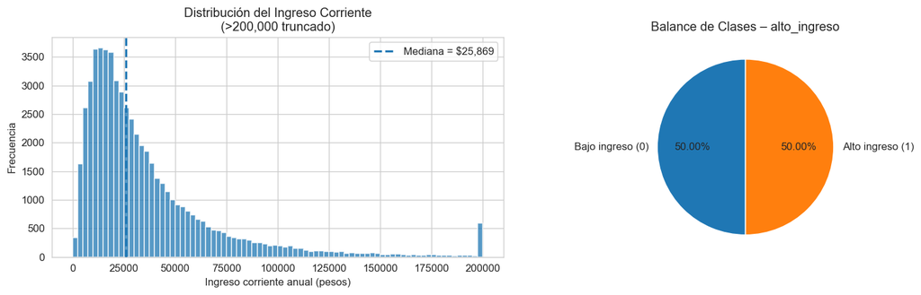

```python
fig, ax = plt.subplots(1, 2, figsize=(13, 4))

# --- Histograma ---
ax[0].hist(df['ing_cor'].clip(upper=200_000), bins=80,
           alpha=0.75, edgecolor='white')
ax[0].axvline(mediana_ing, linestyle='--', linewidth=2,
              label=f'Mediana = ${mediana_ing:,.0f}')
ax[0].set(title='Distribución del Ingreso Corriente\n(>200,000 truncado)',
          xlabel='Ingreso corriente anual (pesos)',
          ylabel='Frecuencia')
ax[0].legend()

# --- Pie chart ---
ax[1].pie([vc[0], vc[1]],
          labels=['Bajo ingreso (0)', 'Alto ingreso (1)'],
          autopct='%1.2f%%', startangle=90)
ax[1].set_title('Balance de Clases – alto_ingreso')
plt.tight_layout()
plt.show()
```

Se muestra la distribución de ing_cor truncando los valores superiores a 200,000 pesos para evitar que la cola larga de ingresos extremos distorsione la escala y permita apreciar mejor la forma de la distribución. La distribución es prácticamente perfecta (50/50), consecuencia directa de utilizar la mediana. Este balance es muy favorable: evita el sesgo hacia la clase mayoritaria que se observa en datasets desbalanceados y permite que métricas como accuracy sean representativas del desempeño real.

## 2. Separación de Datos y Selección de Variables

```python
features = ['sexo_jefe', 'edad_jefe', 'educa_jefe', 'tot_integ', 'menores',
            'mayores', 'ocupados', 'percep_ing', 'tam_loc', 'est_socio']

X = df[features].copy()
y = df['alto_ingreso'].copy()
```

Para construir el modelo de clasificación, se eligen únicamente variables sociodemográficas del hogar que no estén directamente relacionadas con la composición del ingreso. Esto evita problemas de multicolinealidad severa, ya que si se incluyeran variables que ya son componentes del ingreso (como los montos de becas o jubilaciones), el modelo tendría dificultades para identificar el efecto independiente de cada predictor.

Estas características describen la composición y el contexto del hogar sin incluir directamente las cantidades de ingreso, lo que permite analizar su poder predictivo sobre la probabilidad de que el hogar se encuentre por arriba o por debajo de la mediana nacional.

```python
x_train, x_test, y_train, y_test = train_test_split(X,y, test_size=0.2, random_state=42, stratify=y)
x_train.shape, x_test.shape, y_train.shape, y_test.shape
```

```
((46500, 10), (11625, 10), (46500,), (11625,))
```

Se divide el conjunto de datos en dos partes: 80% para entrenamiento y 20% para prueba, usando train_test_split. Se estratifica según y para mantener el balance de clases (50/50) en ambas particiones. La semilla random_state=42 asegura reproducibilidad.

Dimensiones resultantes:

- Entrenamiento: 46,500 hogares y 10 variables predictoras.
- Prueba: 11,625 hogares y 10 variables predictoras.

De esta forma, se reservan datos no vistos para evaluar el rendimiento del modelo, garantizando que tanto entrenamiento como prueba reflejen la misma distribución de clases.

```python
scaler = StandardScaler()
X_train_s = scaler.fit_transform(X_train)
X_test_s  = scaler.transform(X_test)
```

Se estandarizan las variables numéricas para que tengan media cero y desviación estándar uno, evitando que diferencias de escala afecten al modelo.

Se crea un StandardScaler y se aplica fit_transform() a los datos de entrenamiento para calcular los parámetros y transformarlos. Luego, se usa transform() sobre los datos de prueba con los mismos parámetros, evitando que información del conjunto de prueba influya en el preprocesamiento.

```python
conjuntos = {
    'Dataset original': y,
    'Entrenamiento':    y_train,
    'Prueba':           y_test
}

print(f"{'Conjunto':<22} {'n':>7} {'Clase 0':>10} {'Clase 1':>10} {'Prop. Clase 1':>15}")
print("-" * 67)
for nombre, serie in conjuntos.items():
    n  = len(serie)
    c0 = (serie == 0).sum()
    c1 = (serie == 1).sum()
    p1 = c1 / n
    print(f"{nombre:<22} {n:>7,} {c0:>10,} {c1:>10,} {p1:>14.2%}")
```

```
Conjunto                     n    Clase 0    Clase 1   Prop. Clase 1
-------------------------------------------------------------------
Dataset original        58,125     29,064     29,061         50.00%
Entrenamiento           46,500     23,251     23,249         50.00%
Prueba                  11,625      5,813      5,812         50.00%
```

Para confirmar que la estratificación funcionó correctamente, se comparan las distribuciones de la variable alto_ingreso en el conjunto original, el de entrenamiento y el de prueba.

Esto confirma que la división con stratify=y preservó exactamente la proporción de clases en ambos subconjuntos, garantizando que el modelo se entrene y evalúe con la misma distribución que los datos originales.

## 3. Evaluación mediante Validación Cruzada

```python
model_cv = LogisticRegression(max_iter=1000, random_state=42)
skf      = StratifiedKFold(n_splits=5, shuffle=True, random_state=42)

cv_results = cross_validate(
    model_cv, X_train_s, y_train, cv=skf,
    scoring=['accuracy', 'precision', 'recall', 'f1', 'roc_auc'],
    return_train_score=False
)

metrics_labels = {'accuracy': 'Accuracy', 'precision': 'Precisión',
                  'recall': 'Recall', 'f1': 'F1', 'roc_auc': 'AUC'}
metrics_keys   = list(metrics_labels.keys())

header = f"{'Pliegue':<10}" + "".join(f"{metrics_labels[m]:>12}" for m in metrics_keys)
print(header)
print("-" * 70)
for i in range(5):
    row = f"{'Pliegue ' + str(i+1):<10}" + "".join(
        f"{cv_results['test_'+m][i]:>12.4f}" for m in metrics_keys)
    print(row)
print("-" * 70)
row_avg = f"{'Promedio':<10}" + "".join(
    f"{cv_results['test_'+m].mean():>12.4f}" for m in metrics_keys)
row_std = f"{'±  DE':<10}" + "".join(
    f"{cv_results['test_'+m].std():>12.4f}" for m in metrics_keys)
print(row_avg)
print(row_std)
```

```
Pliegue       Accuracy   Precisión      Recall          F1         AUC
----------------------------------------------------------------------
Pliegue 1       0.7499      0.7575      0.7351      0.7461      0.8345
Pliegue 2       0.7635      0.7685      0.7544      0.7614      0.8409
Pliegue 3       0.7601      0.7615      0.7574      0.7595      0.8384
Pliegue 4       0.7585      0.7614      0.7529      0.7571      0.8426
Pliegue 5       0.7597      0.7703      0.7399      0.7548      0.8359
----------------------------------------------------------------------
Promedio        0.7583      0.7638      0.7479      0.7558      0.8385
±  DE           0.0045      0.0048      0.0088      0.0053      0.0030
```

Para obtener una estimación más robusta del rendimiento del modelo sin depender de una sola partición entrenamiento-validación, se aplica validación cruzada estratificada de 5 pliegues (5-fold stratified cross-validation) sobre el conjunto de entrenamiento.

- Los datos de entrenamiento se dividen en 5 partes iguales (pliegues), manteniendo la misma proporción de clases en cada pliegue (estratificación).
- En cada iteración, se usan 4 pliegues para entrenar el modelo y el quinto para validar.
- El proceso se repite 5 veces, rotando el pliegue de validación, y al final se promedian las métricas obtenidas.

Ventajas de este método:

- Reduce la varianza en la estimación del desempeño, ya que se promedian resultados de 5 evaluaciones distintas.
- Todos los datos de entrenamiento participan tanto en entrenamiento como en validación en alguna iteración, aprovechando mejor la información disponible.
- Proporciona intervalos de confianza naturales a través de la desviación estándar de las métricas entre pliegues.

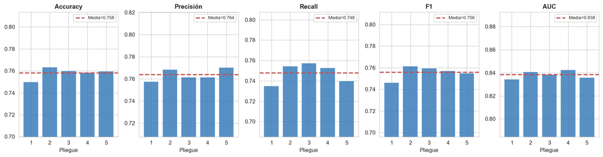

```python
fig, axes = plt.subplots(1, 5, figsize=(15, 4), sharey=False)

for ax, key in zip(axes, metrics_keys):
    vals = cv_results[f'test_{key}']
    ax.bar(range(1, 6), vals, color='#2E75B6', alpha=0.8, edgecolor='white')
    ax.axhline(vals.mean(), color='#C0504D', lw=2, linestyle='--', label=f'Media={vals.mean():.3f}')
    ax.set_title(metrics_labels[key], fontsize=11, fontweight='bold')
    ax.set_xlabel('Pliegue')
    ax.set_ylim(max(0, vals.min() - 0.05), min(1, vals.max() + 0.05))
    ax.legend(fontsize=8)
    ax.set_xticks(range(1, 6))

plt.tight_layout()
plt.show()
```

Una vez obtenidas las métricas en cada pliegue, se generan gráficos de barras para visualizar la distribución de los cinco indicadores (Accuracy, Precisión, Recall, F1 y AUC) a lo largo de las cinco iteraciones. Cada gráfico incluye una línea horizontal punteada que representa el valor promedio de la métrica correspondiente.

## 4. Entrenamiento Final y Evaluación en el Conjunto de Prueba

```python
model = LogisticRegression(max_iter=1000, random_state=42)
model.fit(X_train_s, y_train)

y_pred = model.predict(X_test_s)
y_prob = model.predict_proba(X_test_s)[:, 1]

# Métricas
acc  = accuracy_score(y_test, y_pred)
prec = precision_score(y_test, y_pred)
rec  = recall_score(y_test, y_pred)
f1   = f1_score(y_test, y_pred)
auc  = roc_auc_score(y_test, y_prob)
cm   = confusion_matrix(y_test, y_pred)

print("MÉTRICAS – CONJUNTO DE PRUEBA")
print(f"Accuracy  : {acc:.4f}")
print(f"Precisión : {prec:.4f}")
print(f"Recall    : {rec:.4f}")
print(f"F1-Score  : {f1:.4f}")
print(f"AUC-ROC   : {auc:.4f}")
```

```
MÉTRICAS – CONJUNTO DE PRUEBA
Accuracy  : 0.7681
Precisión : 0.7693
Recall    : 0.7658
F1-Score  : 0.7675
AUC-ROC   : 0.8479
```

Una vez validado el modelo mediante validación cruzada, se procede a entrenar la versión final utilizando todos los datos de entrenamiento (46,500 hogares). Esto permite aprovechar al máximo la información disponible antes de medir su rendimiento real sobre el conjunto de prueba (11,625 hogares), que ha permanecido completamente aislado durante todo el proceso de selección y validación.

Se ajusta una regresión logística con los mismos hiperparámetros usados en la validación cruzada y se generan las predicciones sobre el conjunto de prueba. Las métricas obtenidas son las siguientes:

- Accuracy: 0.7681
- Precisión: 0.7693
- Recall: 0.7658
- F1-Score: 0.7675
- AUC-ROC: 0.8479

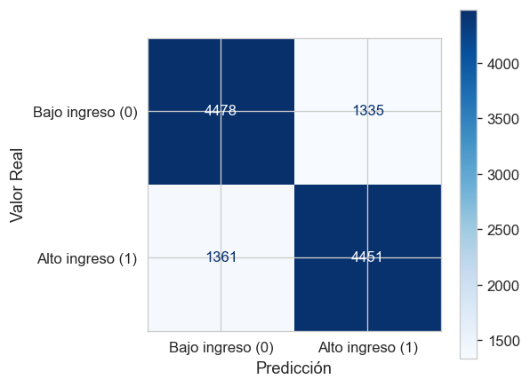

```
Verdaderos Negativos (TN): 4,478  — Bajo ingreso correctamente clasificados
Falsos Positivos     (FP): 1,335  — Bajo ingreso clasificados como alto ingreso
Falsos Negativos     (FN): 1,361  — Alto ingreso clasificados como bajo ingreso
Verdaderos Positivos (TP): 4,451  — Alto ingreso correctamente clasificados
```

```python
fig, ax = plt.subplots(figsize=(5, 4))
disp = ConfusionMatrixDisplay(confusion_matrix=cm,
                               display_labels=['Bajo ingreso (0)', 'Alto ingreso (1)'])
disp.plot(ax=ax, colorbar=True, cmap='Blues')
ax.set_xlabel('Predicción', fontsize=11)
ax.set_ylabel('Valor Real', fontsize=11)
plt.tight_layout()
plt.show()

tn, fp, fn, tp = cm.ravel()
print(f"Verdaderos Negativos (TN): {tn:,}  — Bajo ingreso correctamente clasificados")
print(f"Falsos Positivos     (FP): {fp:,}  — Bajo ingreso clasificados como alto ingreso")
print(f"Falsos Negativos     (FN): {fn:,}  — Alto ingreso clasificados como bajo ingreso")
print(f"Verdaderos Positivos (TP): {tp:,}  — Alto ingreso correctamente clasificados")
```

Los valores obtenidos son:

- Verdaderos Negativos (TN): 4,478 hogares de bajo ingreso correctamente clasificados.
- Falsos Positivos (FP): 1,335 hogares de bajo ingreso que el modelo etiquetó erróneamente como alto ingreso.
- Falsos Negativos (FN): 1,361 hogares de alto ingreso clasificados incorrectamente como bajo ingreso.
- Verdaderos Positivos (TP): 4,451 hogares de alto ingreso bien identificados.

Interpretación de los resultados: El modelo acierta en aproximadamente 4,500 casos de cada clase, lo que representa un buen nivel de precisión global. Lo más destacable es la simetría de los errores: los falsos positivos (1,335) y falsos negativos (1,361) son prácticamente iguales. Esto es exactamente lo que se espera en un problema con clases perfectamente balanceadas y donde el umbral de clasificación (0.5 por defecto) no introduce sesgo hacia ninguna de las dos categorías.

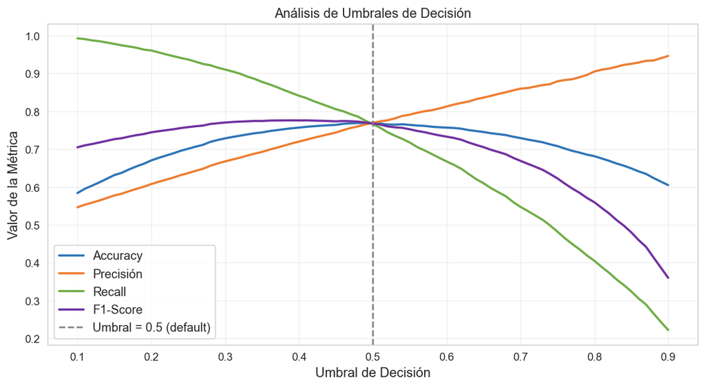

```python
thresholds_range = np.linspace(0.1, 0.9, 81)
accs, precs, recs, f1s = [], [], [], []

for t in thresholds_range:
    yp = (y_prob >= t).astype(int)
    accs.append(accuracy_score(y_test, yp))
    precs.append(precision_score(y_test, yp, zero_division=0))
    recs.append(recall_score(y_test, yp, zero_division=0))
    f1s.append(f1_score(y_test, yp, zero_division=0))

fig, ax = plt.subplots(figsize=(9, 5))
ax.plot(thresholds_range, accs,  label='Accuracy',  color='#2E75B6', lw=2)
ax.plot(thresholds_range, precs, label='Precisión',  color='#ED7D31', lw=2)
ax.plot(thresholds_range, recs,  label='Recall',     color='#70AD47', lw=2)
ax.plot(thresholds_range, f1s,   label='F1-Score',   color='#7030A0', lw=2)
ax.axvline(0.5, color='gray', linestyle='--', lw=1.5, label='Umbral = 0.5 (default)')
ax.set_xlabel('Umbral de Decisión', fontsize=12)
ax.set_ylabel('Valor de la Métrica', fontsize=12)
ax.set_title('Análisis de Umbrales de Decisión', fontsize=12)
ax.legend(fontsize=11)
ax.grid(alpha=0.3)
plt.tight_layout()
plt.show()
```

El umbral por defecto de 0.5 asume que ambos errores (FP y FN) tienen el mismo costo, lo cual es adecuado para un problema balanceado como este. Sin embargo, en aplicaciones prácticas puede interesar explorar umbrales alternativos según el objetivo de política pública.

## 5. Curva ROC y AUC

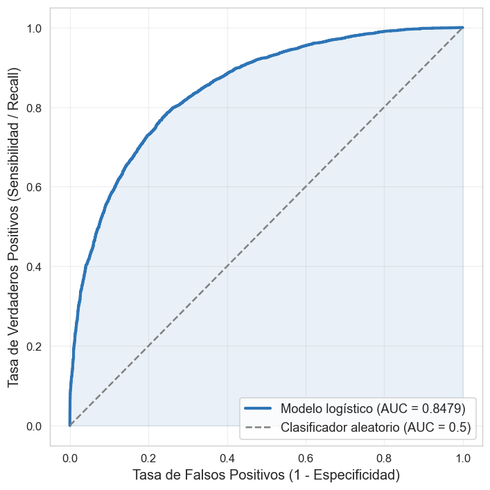

```
AUC = 0.8479
```

```python
# Curva ROC
fpr, tpr, thresholds_roc = roc_curve(y_test, y_prob)

fig, ax = plt.subplots(figsize=(6, 6))
ax.plot(fpr, tpr, color='#2E75B6', lw=2.5, label=f'Modelo logístico (AUC = {auc:.4f})')
ax.plot([0, 1], [0, 1], color='gray', lw=1.5, linestyle='--', label='Clasificador aleatorio (AUC = 0.5)')
ax.fill_between(fpr, tpr, alpha=0.10, color='#2E75B6')
ax.set_xlabel('Tasa de Falsos Positivos (1 - Especificidad)', fontsize=12)
ax.set_ylabel('Tasa de Verdaderos Positivos (Sensibilidad / Recall)', fontsize=12)
ax.legend(fontsize=11, loc='lower right')
ax.grid(alpha=0.3)
plt.tight_layout()
plt.show()

print(f"AUC = {auc:.4f}")
```

La curva ROC (Receiver Operating Characteristic) es una herramienta fundamental para evaluar la capacidad de un clasificador binario independientemente del umbral de decisión elegido. En el gráfico se representa la tasa de verdaderos positivos (sensibilidad o recall) en el eje vertical frente a la tasa de falsos positivos (1 - especificidad) en el eje horizontal, para todos los posibles puntos de corte de la probabilidad predicha.

El área bajo la curva (AUC) resume esta información en un solo número:

- AUC = 0.5: el modelo no discrimina mejor que el azar (línea diagonal punteada).
- AUC = 1.0: clasificación perfecta.
- AUC = 0.848: el modelo logístico se sitúa claramente por encima de la diagonal, indicando una buena capacidad discriminativa.

Interpretación práctica del AUC: Una forma intuitiva de entender el AUC es: si se toma un hogar de alto ingreso y otro de bajo ingreso al azar, el modelo asignará una probabilidad más alta al primero en el 84.8% de las ocasiones. Este valor supera ampliamente el 50% del azar y confirma que las variables sociodemográficas seleccionadas contienen información relevante para distinguir entre ambos grupos.

Consistencia con validación cruzada: El AUC obtenido en el conjunto de prueba (0.8479) es prácticamente idéntico al promedio de la validación cruzada (0.839), lo que refuerza la confianza en la estabilidad del modelo y en que no existe sobreajuste.

## 6. Comparación: Validación Cruzada vs. Conjunto de Prueba

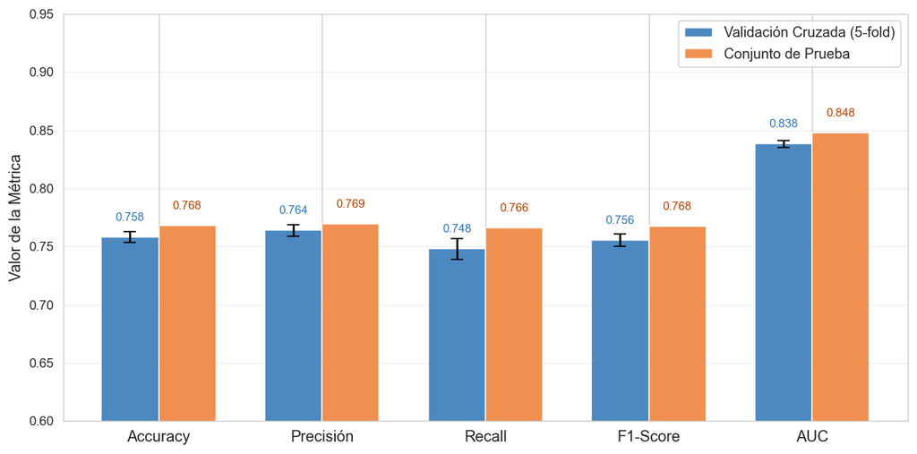

```
Métrica           CV Media    CV ± DE     Prueba   Diferencia
------------------------------------------------------------
Accuracy            0.7583     0.0045     0.7681      +0.0097
Precisión           0.7638     0.0048     0.7693      +0.0054
Recall              0.7479     0.0088     0.7658      +0.0179
F1-Score            0.7558     0.0053     0.7675      +0.0118
AUC                 0.8385     0.0030     0.8479      +0.0095
```

```python
# Comparación visual CV vs Prueba
metrics_disp = ['accuracy', 'precision', 'recall', 'f1', 'roc_auc']
labels_disp  = ['Accuracy', 'Precisión', 'Recall', 'F1-Score', 'AUC']
cv_means = [cv_results[f'test_{m}'].mean() for m in metrics_disp]
cv_stds  = [cv_results[f'test_{m}'].std()  for m in metrics_disp]
test_vals = [acc, prec, rec, f1, auc]

x = np.arange(len(metrics_disp))
width = 0.35

fig, ax = plt.subplots(figsize=(10, 5))
b1 = ax.bar(x - width/2, cv_means, width, yerr=cv_stds, capsize=5,
            label='Validación Cruzada (5-fold)', color='#2E75B6', alpha=0.85)
b2 = ax.bar(x + width/2, test_vals, width,
            label='Conjunto de Prueba', color='#ED7D31', alpha=0.85)
ax.set_xticks(x)
ax.set_xticklabels(labels_disp, fontsize=12)
ax.set_ylim(0.60, 0.95)
ax.set_ylabel('Valor de la Métrica', fontsize=12)
ax.legend(fontsize=11)
ax.grid(axis='y', alpha=0.3)

# Anotar valores
for rect, v in zip(b1, cv_means):
    ax.text(rect.get_x() + rect.get_width()/2, rect.get_height() + 0.012,
            f'{v:.3f}', ha='center', va='bottom', fontsize=9, color='#2E75B6')
for rect, v in zip(b2, test_vals):
    ax.text(rect.get_x() + rect.get_width()/2, rect.get_height() + 0.012,
            f'{v:.3f}', ha='center', va='bottom', fontsize=9, color='#B54200')

plt.tight_layout()
plt.show()

# Tabla comparativa
print(f"{'Métrica':<15} {'CV Media':>10} {'CV ± DE':>10} {'Prueba':>10} {'Diferencia':>12}")
print("-" * 60)
for lbl, key, cv_m, cv_s, tv in zip(labels_disp, metrics_disp, cv_means, cv_stds, test_vals):
    diff = tv - cv_m
    print(f"{lbl:<15} {cv_m:>10.4f} {cv_s:>10.4f} {tv:>10.4f} {diff:>+12.4f}")
```

## 7. Interpretación del Modelo

```python
feature_labels = {
    'educa_jefe': 'Escolaridad del jefe',
    'ocupados':   'Miembros ocupados',
    'est_socio':  'Estrato socioeconómico',
    'edad_jefe':  'Edad del jefe',
    'percep_ing': 'Perceptores de ingreso',
    'mayores':    'Miembros mayores de edad',
    'tot_integ':  'Total de integrantes',
    'sexo_jefe':  'Sexo del jefe',
    'menores':    'Menores de edad',
    'tam_loc':    'Tamaño de localidad'
}

coef_df = pd.DataFrame({
    'Variable': features,
    'Descripción': [feature_labels[f] for f in features],
    'Coeficiente': model.coef_[0],
    'Odds Ratio': np.exp(model.coef_[0])
}).sort_values('Coeficiente', ascending=False)

coef_df['Dirección'] = coef_df['Coeficiente'].apply(lambda x: '↑ Positiva' if x > 0 else '↓ Negativa')

print(f"{'Descripción':<30} {'Coeficiente':>14} {'Odds Ratio':>12} {'Dirección':>12}")
print("-" * 70)
for _, row in coef_df.iterrows():
    print(f"{row['Descripción']:<30} {row['Coeficiente']:>14.4f} {row['Odds Ratio']:>12.4f} {row['Dirección']:>12}")
```

```
Descripción                       Coeficiente   Odds Ratio    Dirección
----------------------------------------------------------------------
Escolaridad del jefe                   0.8949       2.4471   ↑ Positiva
Miembros ocupados                      0.7490       2.1148   ↑ Positiva
Estrato socioeconómico                 0.5715       1.7709   ↑ Positiva
Edad del jefe                          0.3076       1.3601   ↑ Positiva
Perceptores de ingreso                 0.2180       1.2436   ↑ Positiva
Miembros mayores de edad               0.2171       1.2424   ↑ Positiva
Total de integrantes                   0.1260       1.1343   ↑ Positiva
Sexo del jefe                         -0.0143       0.9858   ↓ Negativa
Menores de edad                       -0.0672       0.9350   ↓ Negativa
Tamaño de localidad                   -0.2854       0.7517   ↓ Negativa
```

Los coeficientes de la regresión logística indican la dirección y magnitud del efecto de cada variable sobre la probabilidad de que un hogar tenga ingresos superiores a la mediana. Dado que las variables fueron estandarizadas, los coeficientes representan el cambio en el log-odds (logaritmo de la razón de momios) por cada incremento de una desviación estándar en el predictor. Al aplicar la exponencial se obtienen las razones de momios (odds ratios), que facilitan la interpretación: un odds ratio mayor a 1 indica que la variable aumenta la probabilidad de pertenecer al grupo de alto ingreso, mientras que menor a 1 la disminuye.

Los resultados muestran que la escolaridad del jefe es el factor más influyente (odds ratio = 2.45): por cada desviación estándar adicional en años de educación, la odds de ser un hogar de alto ingreso se multiplica por 2.45. Le siguen el número de miembros ocupados (2.11) y el estrato socioeconómico (1.77), todos con efectos positivos relevantes. También aumentan la probabilidad la edad del jefe, los perceptores de ingreso y los miembros mayores de edad, aunque con menor magnitud.

En el lado negativo, el tamaño de localidad (que aumenta en zonas más rurales) reduce la odds de alto ingreso en un 25% (odds ratio = 0.75). La presencia de menores de edad también tiene un efecto negativo moderado (0.94), mientras que el sexo del jefe (mujer) muestra una asociación negativa muy leve (0.99), prácticamente nula en términos prácticos.

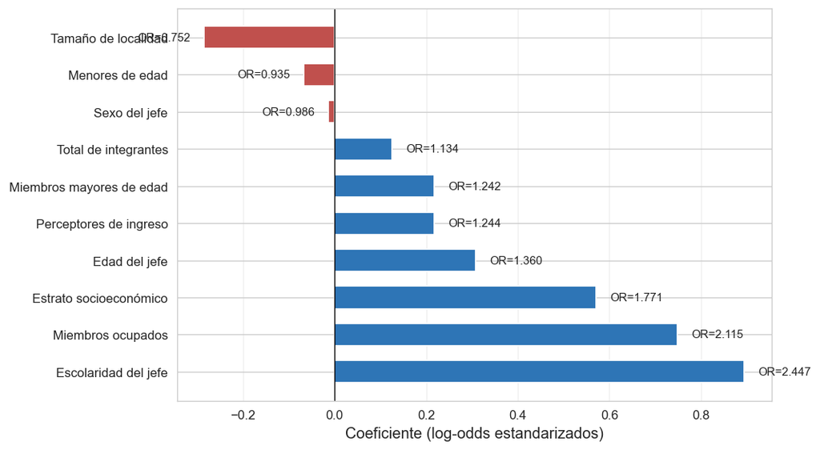

```python
fig, ax = plt.subplots(figsize=(9, 5))
colors = ['#2E75B6' if c > 0 else '#C0504D' for c in coef_df['Coeficiente']]
descs  = [feature_labels[f] for f in coef_df['Variable']]

bars = ax.barh(descs, coef_df['Coeficiente'], color=colors, edgecolor='white', height=0.6)
ax.axvline(0, color='black', linewidth=0.8)
ax.set_xlabel('Coeficiente (log-odds estandarizados)', fontsize=12)
ax.grid(axis='x', alpha=0.3)

# Anotar odds ratios
for bar, or_val in zip(bars, coef_df['Odds Ratio']):
    x_pos = bar.get_width()
    offset = 0.03 if x_pos >= 0 else -0.03
    ha = 'left' if x_pos >= 0 else 'right'
    ax.text(x_pos + offset, bar.get_y() + bar.get_height()/2,
            f'OR={or_val:.3f}', va='center', ha=ha, fontsize=9)

plt.tight_layout()
plt.show()
```

Los coeficientes de la regresión logística, al estar las variables estandarizadas, indican el cambio en el log-odds de pertenecer al grupo de alto ingreso por cada incremento de una desviación estándar en el predictor. Al exponenciarlos, obtenemos las razones de momios (odds ratios), que muestran cuánto se multiplica la probabilidad de ser de alto ingreso cuando la variable aumenta en una desviación típica. Valores superiores a 1 indican un efecto positivo; inferiores a 1, negativo.

Variables que disminuyen la probabilidad de alto ingreso

- Tamaño de localidad (OR = 0.752): En la codificación de la ENIGH, valores altos indican localidades más rurales. El efecto negativo confirma la brecha urbano-rural: vivir en zonas rurales reduce la probabilidad de tener ingresos altos.
- Menores de edad (OR = 0.935): Más niños en el hogar implican mayores gastos sin aportar ingresos, lo que disminuye la probabilidad de superar la mediana.
- Sexo del jefe (OR = 0.986): El efecto es prácticamente nulo; controlando por otras variables, el sexo del jefe no discrimina el nivel de ingreso.

## 8. Conclusiones

En esta actividad se logró armar un modelo de regresión logística para predecir qué hogares mexicanos tienen ingresos por encima de la mediana nacional, usando solo datos sociodemográficos básicos (como edad y educación del jefe, cuántos trabajan en la casa, si viven en zona rural, etc.). La idea es pasar de un problema de regresión (predecir el ingreso exacto) a uno de clasificación binaria, que es más útil para ciertas aplicaciones de política pública y además nos daba clases balanceadas por construcción.

El modelo alcanzó un AUC de 0.848 en el conjunto de prueba, lo que significa que discrimina bien entre hogares de alto y bajo ingreso. El accuracy fue de 76.8%, y tanto precisión como recall anduvieron por el mismo rango (alrededor del 77%), así que no hay sesgo hacia ninguna clase. La validación cruzada de 5 pliegues mostró que el modelo es estable (desviaciones estándar chiquitas, menores a 0.009) y los valores de prueba quedaron dentro de lo esperado, confirmando que no hay sobreajuste.

En cuanto a los factores que más influyen, la escolaridad del jefe se llevó el primer lugar: por cada desviación estándar extra en educación, la probabilidad de ser de alto ingreso se multiplica por 2.45. Le siguen los miembros ocupados (OR=2.11) y el estrato socioeconómico (OR=1.77). Del lado negativo, vivir en localidades más rurales (tam_loc) reduce la probabilidad en un 25% (OR=0.75), lo que refleja esa brecha urbano-rural tan marcada en México. También los menores de edad en el hogar juegan en contra (OR=0.93), probablemente por la carga económica que representan.

El modelo tiene sus limitaciones: asume relaciones lineales (en el mundo de los log-odds) y hay cosas que no podemos medir, como herencias, contactos o suerte, que también afectan el ingreso. Por eso el AUC no llega a 1, y tal vez con modelos más flexibles (como gradient boosting) se podría obtener un poco más de precisión, aunque se pierde interpretabilidad.

Un punto importante es que la validación cruzada funcionó súper bien para estimar el desempeño real: las métricas que se obtuvieron en CV fueron ligeramente conservadoras pero muy cercanas a las de prueba. Eso nos da confianza en que el método sirve para evaluar modelos sin necesidad de quemar los datos de prueba durante el desarrollo.

En resumen, el modelo sirve como herramienta para entender los determinantes del ingreso y podría orientar políticas enfocadas en educación, empleo y desarrollo rural.

## 9. Referencias

Inteligencia Artificial (2026) Dr Antonio Martinez Torteya

Instituto Nacional de Estadística y Geografía. (2014). Encuesta Nacional de Ingresos y Gastos de los Hogares (ENIGH) 2014. https://www.inegi.org.mx/programas/enigh/nc/2014/

scikit-learn developers. (s. f.). Logistic regression. https://scikit-learn.org/stable/modules/linear_model.html#logistic-regression

scikit-learn developers. (s. f.). train_test_split. https://scikit-learn.org/stable/modules/generated/sklearn.model_selection.train_test_split.html

scikit-learn developers. (s. f.). StandardScaler. https://scikit-learn.org/stable/modules/generated/sklearn.preprocessing.StandardScaler.html

scikit-learn developers. (s. f.). Cross-validation: evaluating estimator performance. https://scikit-learn.org/stable/modules/cross_validation.html

scikit-learn developers. (s. f.). Classification metrics. https://scikit-learn.org/stable/modules/model_evaluation.html

scikit-learn developers. (s. f.). confusion_matrix. https://scikit-learn.org/stable/modules/generated/sklearn.metrics.confusion_matrix.html

scikit-learn developers. (s. f.). Receiver Operating Characteristic (ROC). https://scikit-learn.org/stable/auto_examples/model_selection/plot_roc.html

Google Developers. (s. f.). ROC and AUC. https://developers.google.com/machine-learning/crash-course/classification/roc-and-auc

Este trabajo fue elaborado con apoyo de Claude.